# Twitter Analysis

Mohin Banker

2/16/2018

## Cleaning Data

First, we read in the data and clean date-times and classify datatypes. Before, I mapped Unicode hex codes to emojis and symbols, but now realize that having these values isn’t very useful. Therefore, we remove all unrecognized symbols.

Previously, I was replacing hex codes with their corresponding emojis. Credit to Kate Lyons and Jessica Peterka-Bonetta for developing a free dictionary for translating Unicode to emojis. Unfortunately, the literature on using emojis in sentiment analyses is sparse and unexplored. Emojis were generally used frequently (about 1/8 of tweets had some kind of emoji or symbol), but no single emoji was used with extreme frequency. Further analysis would involve coding obvious emojis to their corresponding sentiments (e.g. laughter, love, or heart emojis coded to positive sentiments).

[output not shown]

## Exploratory Analysis

Next, we want to familiarize ourselves with how our data look.

Looking at individual columns, there are a few interesting variables. The richest variable is `text`, which contains the actual text of the tweets. Then we have the Twitter handle that authored the tweet, the account the tweet is replying to, metrics like favorites and retweets, and administrative variables like time and location of the tweet’s origination. All other variables are either superfluous or not useful.

```
## Observations: 753,804
## Variables: 29
## $ idx1          <dbl> 3, 4, 5, 6, 7, 8, 9, 10, 11, 12, 13, 14, 15, 16,...
## $ idx2          <int> 2, 3, 4, 5, 6, 7, 8, 9, 10, 11, 12, 13, 14, 15, ...
## $ idx3          <dbl> 1, 2, 3, 4, 5, 6, 7, 8, 9, 10, 11, 12, 13, 14, 1...
## $ text          <chr> "@KristySwansonXO Like this one? https://t.co/Ll...
## $ favorited     <lgl> FALSE, FALSE, FALSE, FALSE, FALSE, FALSE, FALSE,...
## $ favoriteCount <dbl> 0, 0, 0, 0, 0, 0, 0, 0, 0, 0, 0, 0, 0, 0, 0, 0, ...
## $ replyToSN     <chr> "KristySwansonXO", "LapoBK", "Lauramchapman", "S...
## $ created       <dttm> 2017-02-23 22:27:55, 2017-02-23 22:22:32, 2017-...
## $ truncated     <lgl> FALSE, FALSE, FALSE, FALSE, FALSE, FALSE, FALSE,...
## $ replyToSID    <chr> "834866636360392704", "834871431162888192", "834...
## $ id            <chr> "834892573365972995", "834891215866851328", "834...
## $ replyToUID    <chr> "45033456", "2373874716", "34731404", "228760178...
## $ statusSource  <chr> "<a href=\"\"http://twitter.com\"\" rel=\"\"nofo...
```

[output cut: 16 more lines]

The following is a tabulation of the number of unique variables each variables takes. We see that there are 115 unique companies. Additionally, all the date and time variables are correctly coded. It’s unclear what `idx2` and `idx3` are supposed to represent. The boolean variables `favorited` and `retweeted` are incorrectly coded. Assumedly, we only have non-retweets in our sample because there is a single unique value for `isRetweet`.

```
##     idx1   idx2 idx3   text favorited favoriteCount replyToSN created
## 1 753804 196284 3200 709979         1          5565    413242  711658
##   truncated replyToSID     id replyToUID statusSource screenName
## 1         2     559879 753804     413585          108        115
##   retweetCount isRetweet retweeted longitude latitude isReply date  time
## 1         3144         1         1        24       24       2 1898 82239
##   year month day hour minute second website
## 1    8    12  31   24     60     60     108
```

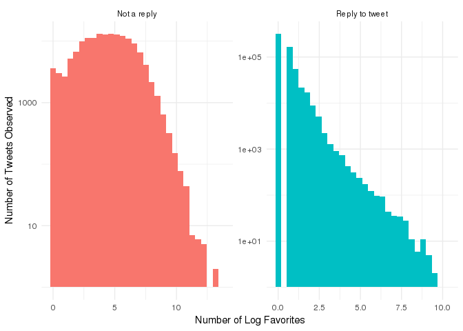

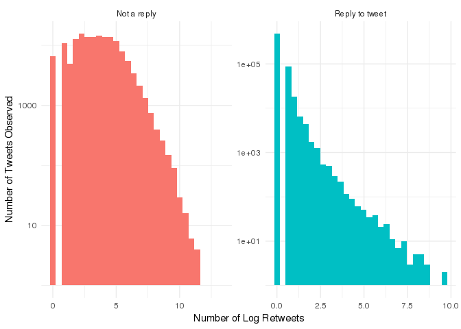

Looking at the frequency of tweets over time, there seems to be an interesting spike in tweet frequency at the beginning of 2017. There isn’t a clear explanation for this observation, especially since there aren’t any spikes as similar times during other years. Otherwise, the distribution is expectedly left-skewed as companies increase social media interactions over time.

The second graph shows a distribution of tweet frequencies over time by individual companies. There are stark differences in behavior. Some companies maintain high frequency of tweets, while other keep low frequencies of tweets. Other companies gradually increase tweeting, while another group tweets less predictably and tweets with high frequency every so often.

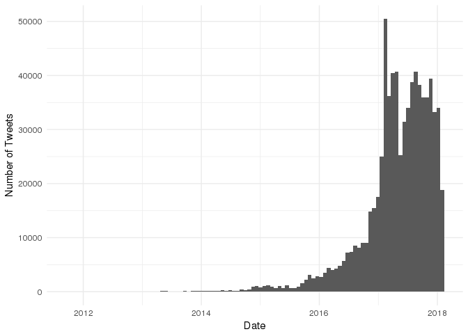

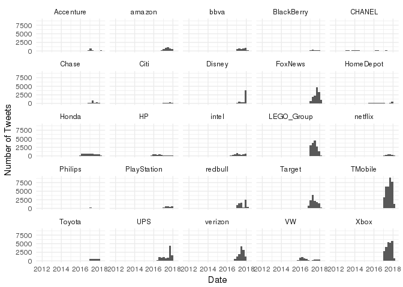

As for locational data, most companies don’t disclose their location when tweeting. We only find 26 observations that have a location, which makes the data useless.

| screenName | locationTweets |
| --- | --- |
| corona | 2 |
| gucci | 23 |
| Lexus | 1 |

Our dataset also provides the platform source of the screenName’s tweet. David Robinson did a [very interesting text analysis](http://varianceexplained.org/r/trump-tweets/) demonstrating why a tweet’s source can be informative. There are a large variety of platforms used, but a large proportion use third-party platforms like Sprinklr, Lithium, Radian6, or Spredfast to manage general customer experience across social media sites.

| website | source |
| --- | --- |
| Sprinklr | 159039 |
| Twitter Web Client | 83157 |
| Lithium Tech. | 76180 |
| Spredfast app | 64310 |
| Radian6 -Social Media Management | 44266 |
| Spredfast | 32990 |
| Lithium Tech | 30417 |
| TweetDeck | 29119 |
| Sparkcentral.com | 28896 |
| LiveWorld Inc | 20212 |
| Sprinklr Prod2 | 20063 |
| Conversocial | 19726 |
| Hootsuite | 15100 |
| Oracle Engage | 12493 |
| Twitter for iPhone | 11177 |
| BIG Connect 2 | 9729 |
| Percolate | 9664 |
| Wilke Global SMART | 8365 |
| Media Studio | 7982 |
| Insightpool | 5538 |

We find each company’s most frequently used method of tweeting. As a note, it might be interesting to look for differences in Twitter usage based on what platform the company uses to write tweets.

| website | screenName | source | sourcePercent |
| --- | --- | --- | --- |
| Radian6 -Social Media Management | Accenture | 1183 | 0.7691808 |
| Twitter Web Client | adidasoriginals | 3007 | 0.4681613 |
| Spredfast app | AEO | 4175 | 0.7999617 |
| Twitter Web Client | Allianz | 599 | 0.5972084 |
| Sprinklr | amazon | 3910 | 0.9453578 |
| Sprinklr | AmericanExpress | 7633 | 0.7833539 |
| Conversocial | Android | 5067 | 0.8533176 |
| Sprinklr | ATT | 9551 | 0.6404050 |
| Sprinklr | Audi | 2743 | 0.9229475 |
| Twitter Web Client | BankofAmerica | 310 | 0.5709024 |
| Facelift Cloud | BASF | 551 | 0.5375610 |
| Sprout Social | bbva | 1743 | 0.4641811 |
| Spredfast app | BestBuy | 8746 | 0.9366031 |
| Radian6 -Social Media Management | BlackBerry | 1180 | 0.9941028 |
| Sprinklr | BMW | 5312 | 0.9977461 |
| Twitter Web Client | Boeing | 249 | 0.4715909 |
| Earshot App | Budweiser | 4417 | 0.5693478 |
| Spredfast app | Burberry | 3836 | 0.6085025 |
| Shoutlet API | CanonUSA | 1645 | 0.6165667 |
| Twitter Web Client | Cartier | 916 | 0.4044150 |
| Spredfast | CaterpillarInc | 3621 | 0.8490035 |
| Twitter Web Client | CHANEL | 2583 | 0.8803681 |
| Sprinklr | Chase | 847 | 0.4964830 |
| Spredfast app | chevrolet | 1698 | 0.3714723 |
| Sprinklr | Cisco | 1848 | 0.7914347 |
| Sprinklr | Citi | 1061 | 0.9584463 |
| Spredfast app | Coach | 205 | 0.4027505 |
| Sprinklr | CocaCola | 16464 | 0.9867546 |
| Social Relationship Management | Colgate | 3217 | 0.8150494 |
| Percolate | corona | 441 | 0.4900000 |

[output cut: 85 more lines]

Now, we look at engagement on tweets through the number of favorites and retweets. Companies involved in entertainment and media like Netflix, ESPN, Disney, and Rockstar Games, which are especially popular with Twitter’s younger demographic, receive more favorites and retweets on average. Interestingly, Nike receives a lot of engagement with its tweets, likely because of how infrequently the screenName tweets, and how it markets with major sports icons.

| screenName | rts | favs | tweets |
| --- | --- | --- | --- |
| Nike | 2692.2961 | 5834.8092 | 152 |
| netflix | 2101.7022 | 5970.8151 | 806 |
| espn | 1089.0677 | 3547.6199 | 1773 |
| Disney | 1017.1439 | 2466.5818 | 1564 |
| RockstarGames | 927.0818 | 3289.0147 | 477 |
| CHANEL | 834.8373 | 1455.0168 | 2913 |
| Xbox | 689.3293 | 1159.7535 | 1148 |
| adidasoriginals | 571.8562 | 1579.3275 | 1252 |
| Starbucks | 541.1747 | 2172.5445 | 292 |
| LouisVuitton | 435.4394 | 920.8512 | 3541 |
| SamsungMobile | 383.9858 | 1118.9683 | 1200 |
| PlayStation | 372.1775 | 1302.4552 | 2502 |
| FoxNews | 341.9851 | 1045.1122 | 13962 |
| Budweiser | 329.1538 | 581.3297 | 364 |
| LEGO_Group | 316.7794 | 531.6975 | 757 |
| Target | 260.8039 | 680.0900 | 311 |
| VictoriasSecret | 256.1895 | 1293.5338 | 1272 |
| Google | 249.1283 | 711.3858 | 1138 |
| CocaCola | 248.1827 | 728.4135 | 208 |
| pepsi | 246.6440 | 368.8307 | 1146 |
| Android | 227.5668 | 559.9741 | 734 |
| Porsche | 226.1846 | 752.7302 | 493 |
| Microsoft | 201.6388 | 420.6118 | 407 |
| BMW | 199.4597 | 853.7346 | 422 |
| Audi | 183.7878 | 696.3829 | 410 |
| Coach | 146.2672 | 368.2731 | 509 |
| SamsungMobileUS | 135.5896 | 619.4245 | 848 |
| Burberry | 132.7936 | 343.5422 | 6138 |
| facebook | 129.2500 | 358.9519 | 104 |
| hm | 115.1360 | 386.0964 | 2698 |

| screenName | rts | favs | tweets |
| --- | --- | --- | --- |
| PlayStation | 211.750000 | 1179.333333 | 24 |
| FoxNews | 59.750000 | 164.500000 | 24 |
| gucci | 53.044444 | 118.022222 | 45 |
| LouisVuitton | 40.166667 | 87.500000 | 18 |
| CHANEL | 36.714286 | 24.904762 | 21 |
| netflix | 27.084139 | 181.649903 | 1034 |
| espn | 22.333333 | 97.833333 | 6 |
| RockstarGames | 18.520000 | 98.160000 | 25 |
| Boeing | 9.452703 | 51.858108 | 148 |
| adidasoriginals | 7.929801 | 24.398182 | 5171 |
| Microsoft | 7.710526 | 17.184210 | 38 |
| hm | 7.304094 | 13.181287 | 513 |
| Fendi | 6.500000 | 13.500000 | 4 |
| Prada | 5.942857 | 4.914286 | 35 |
| SamsungMobile | 5.366197 | 14.690141 | 213 |
| Chase | 5.338235 | 12.820378 | 952 |
| Burberry | 5.156626 | 18.783133 | 166 |
| CanonUSA | 5.000000 | 11.000000 | 1 |
| amazon | 4.122526 | 11.120136 | 2930 |
| corona | 3.317073 | 2.097561 | 41 |
| Nissan | 3.054794 | 11.292237 | 219 |
| intel | 2.715679 | 6.768721 | 2564 |
| Cartier | 2.623844 | 4.516958 | 973 |
| BlackBerry | 2.211268 | 4.985915 | 71 |
| HomeDepot | 2.087690 | 3.455312 | 593 |
| Audi | 2.054645 | 6.370804 | 2562 |
| LOrealParisUSA | 1.705030 | 5.230179 | 1173 |
| HSBC | 1.673469 | 3.489796 | 49 |
| Sony | 1.590563 | 9.494673 | 657 |
| Android | 1.553228 | 2.404689 | 5204 |

We also look at companies that most frequently send reply tweets as a percentage of all tweets. Airline companies like Delta and Southwest use most of their tweets to engage with and manage customers. There doesn’t seem to be a pattern among companies that have a reply rate, there is a mix of industries and screenName size.

| screenName | reply_rate | total_replies |
| --- | --- | --- |
| Delta | 0.9977051 | 35215 |
| SouthwestAir | 0.9963492 | 35479 |
| McDonalds | 0.9953494 | 34458 |
| Costco | 0.9943860 | 1417 |
| Starbucks | 0.9904478 | 30277 |
| TMobile | 0.9881356 | 33481 |
| CocaCola | 0.9875337 | 16477 |
| facebook | 0.9858059 | 7223 |
| Nike | 0.9825788 | 8573 |
| Ford | 0.9811800 | 14285 |
| Target | 0.9754267 | 12345 |
| ZARA | 0.9740103 | 19338 |
| redbull | 0.9711962 | 7283 |
| Walmart | 0.9688693 | 20043 |
| verizon | 0.9681036 | 12262 |
| SamsungMobileUS | 0.9575108 | 19110 |
| Fritolay | 0.9571933 | 7312 |
| Budweiser | 0.9530807 | 7394 |
| ATT | 0.9527960 | 14210 |
| Xbox | 0.9527747 | 23161 |
| LEGO_Group | 0.9509270 | 14669 |
| WholeFoods | 0.9432456 | 16304 |
| Colgate | 0.9366608 | 3697 |
| SUBWAY | 0.9316476 | 4716 |
| Google | 0.9315077 | 15477 |
| NESCAFE | 0.9283880 | 6508 |
| UPS | 0.9249933 | 10322 |
| BMW | 0.9207363 | 4902 |
| VictoriasSecret | 0.9155491 | 13790 |
| Gap | 0.9123460 | 7109 |

## Sentiment Analysis

### NRC Dictionary

We can use word choices to classify whether a tweet or screenName exhibit specific sentiments. We start our sentiment analysis using the NRC dictionary. It has a larger dictionary of words and can classify numerous sentiments. Stopping/filler words like “and”, “of”, “to”, etc. are removed.

In general, companies post tweets with positive sentiments and to a lesser extent, more trustworthy, anticipatory, and joyous tweets. Here is table of total counts of sentiments across all observed tweets.

As a side note, I looked into removing non-English words from the dataset to increase algorithm efficiency and eliminate noise from misspellings, but found existing functions too slow or their dictionaries to be too small. In any case, companies mostly use properly spelled words.

[output not shown]

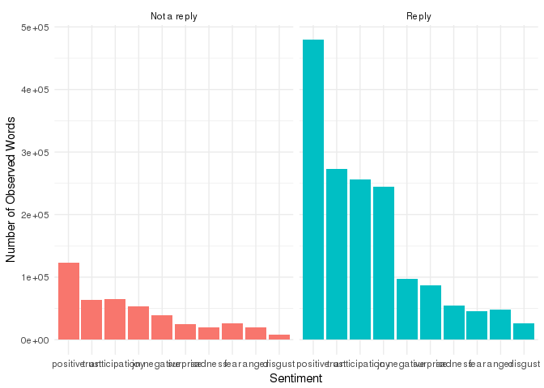

We calculate the proportion of each sentiment that the company expresses as a part of all sentiments, then order each company within each sentiment. So, we find companies representative of each emotion. For example, we find Boeing at the top of the list for “anticipation”, likely because many of their tweets acknowledge the anticipation of flights. Fox News is near the top of anger, disgust, negative, and sadness largely because news stories include such feelings. BBVA is mistakenly at the top of anger/disgust/negative because many of the company’s tweets are in Spanish, and the word “sin” is classified as all of those sentiments, when the word actually translates to “without” in English. Also, “saber” and “leer” are considered negative words when they mean “to know” and “to learn”, respectively.

| test | anger | anticipation | disgust | fear | joy | negative | positive | sadness | surprise | trust |
| --- | --- | --- | --- | --- | --- | --- | --- | --- | --- | --- |
| 1 | bbva | Boeing | bbva | FoxNews | HP | bbva | Costco | marcjacobs | Etsy | Google |
| 2 | verizon | WholeFoods | JohnDeere | RockstarGames | Starbucks | FoxNews | SUBWAY | SAP | Visa | ZARA |
| 3 | RockstarGames | verizon | FoxNews | LouisVuitton | Visa | marcjacobs | Hyundai | CHANEL | Prada | facebook |
| 4 | FoxNews | redbull | Heineken | PlayStation | Target | Budweiser | AmericanExpress | FoxNews | UPS | AmericanExpress |
| 5 | Disney | Hermes_Paris | netflix | bbva | Mastercard | Chase | Audi | Delta | Mastercard | TOMS |
| 6 | Chase | Visa | woot | Disney | Pampers | netflix | Ford | gucci | corona | Fritolay |
| 7 | espn | LouisVuitton | RockstarGames | Heineken | Ford | CHANEL | Porsche | Prada | Fendi | Android |
| 8 | Budweiser | corona | Hermes_Paris | netflix | NESCAFE | woot | WholeFoods | SouthwestAir | WellsFargo | Delta |
| 9 | Heineken | RBC | Fritolay | Burberry | Etsy | RockstarGames | intel | bbva | Gillette | SantanderBankUS |
| 10 | PlayStation | HP | Pampers | espn | IKEAUSA | Heineken | Accenture | netflix | LouisVuitton | generalelectric |
| 11 | marcjacobs | Xbox | espn | gucci | HomeDepot | PlayStation | TOMS | PlayStation | FedEx | HSBC |
| 12 | netflix | HomeDepot | Delta | Philips | WellsFargo | SAP | AEO | Cartier | RBC | Oracle |
| 13 | Burberry | Android | SouthwestAir | IBM | Toyota | espn | BASF | Hermes_Paris | McDonalds | Philips |
| 14 | gucci | Oracle | Gap | SamsungMobile | McDonalds | thomsonreuters | CaterpillarInc | SantanderBankUS | Pampers | AEO |
| 15 | SamsungMobileUS | Budweiser | Coach | thomsonreuters | Xbox | Coach | BlackBerry | Burberry | Target | NESCAFE |
| 16 | Nike | Nike | Sony | BlackBerry | LOrealParisUSA | Disney | CocaCola | espn | amazon | Colgate |
| 17 | Nissan | SantanderBankUS | KelloggsUS | Nissan | CocaCola | gucci | facebook | Nissan | Cartier | Nestle |
| 18 | SamsungMobile | FedEx | PlayStation | Microsoft | corona | Gap | Cartier | Google | Walmart | Hyundai |
| 19 | thomsonreuters | TMobile | ZARA | Allianz | Lexus | SamsungMobile | Siemens | RockstarGames | CHANEL | ATT |
| 20 | woot | VictoriasSecret | Nestle | Nike | Gillette | SamsungMobileUS | SantanderBankUS | AEO | Coach | CaterpillarInc |
| 21 | Nestle | LEGO_Group | SamsungMobileUS | pepsi | amazon | Nissan | Oracle | woot | BestBuy | Danone |
| 22 | Fendi | Gillette | BestBuy | woot | Honda | SouthwestAir | Danone | Gap | Xbox | chevrolet |
| 23 | Lexus | IKEAUSA | McDonalds | Mastercard | VictoriasSecret | Prada | CanonUSA | Coach | Burberry | kraftfoods |
| 24 | Sony | WellsFargo | thomsonreuters | Citi | BestBuy | Allianz | Microsoft | LouisVuitton | Colgate | CanonUSA |
| 25 | pepsi | PlayStation | Nissan | Boeing | Walmart | Nike | IBM | SamsungMobileUS | HersheyCompany | Allianz |
| 26 | ATT | NESCAFE | HersheyCompany | Sony | UniqloUSA | LOrealParisUSA | ZARA | ZARA | redbull | IBM |
| 27 | FedEx | Cisco | Lexus | Cisco | TMobile | JohnDeere | Citi | eBay | Sony | Citi |
| 28 | eBay | Chase | Philips | Accenture | LEGO_Group | Fendi | BMW | pepsi | SamsungMobile | MercedesBenz |
| 29 | Delta | SamsungMobile | ATT | CHANEL | Android | Sony | pepsi | adidasoriginals | marcjacobs | Honda |
| 30 | SouthwestAir | Toyota | BASF | SAP | BMW | eBay | Philips | Fendi | BankofAmerica | FedEx |

Next, we look at common words by each sentiment for non-replies. We expect non-replies to be more indicative of general announcements and marketing.

| anger | anticipation | disgust | fear | joy | negative | positive | sadness | surprise | trust |
| --- | --- | --- | --- | --- | --- | --- | --- | --- | --- |
| shot | watch | john | watch | love | fall | learn | fall | inspired | happy |
| limited | time | winning | shot | happy | sap | love | sap | gift | top |
| lace | ready | feeling | change | perfect | shot | happy | shot | shot | team |
| hit | happy | powerful | journey | holiday | black | join | black | trump | perfect |
| vote | top | treat | lace | favorite | wear | top | art | chance | favorite |
| challenge | perfect | finally | challenge | share | tax | perfect | music | art | share |
| hot | store | death | police | inspired | limited | store | tax | excited | inspired |
| feeling | holiday | boy | feeling | proud | john | holiday | limited | award | proud |
| demand | tomorrow | bad | military | create | lace | favorite | blue | catch | president |
| fight | coming | cancer | fight | gift | hit | share | lace | unique | save |

In contrast, we look at words used in replies, which are typically aimed at customers and complaints. Many of the generally negative words are suggestive of being understanding towards frustrated customers.

| anger | anticipation | disgust | fear | joy | negative | positive | sadness | surprise | trust |
| --- | --- | --- | --- | --- | --- | --- | --- | --- | --- |
| delay | happy | delay | delay | love | wait | love | apologize | hope | happy |
| shout | glad | treat | treat | happy | delay | happy | delay | chance | hope |
| treat | hope | feeling | feeling | glad | treat | glad | treat | luck | team |
| frustration | time | disappointment | change | hope | frustration | hope | feeling | excited | enjoy |
| feeling | enjoy | john | flying | enjoy | forget | enjoy | disappointment | shopping | assist |
| deserve | share | disappointed | shot | share | feeling | assist | regret | sweet | share |
| words | store | hate | hearing | fun | disappointment | share | shot | shout | account |
| wireless | wait | hanging | surprise | perfect | regret | contact | error | treat | confirmation |
| shot | fun | bad | force | favorite | cold | store | unable | birthday | apologize |
| grab | perfect | disappoint | worry | luck | words | customer | music | feeling | provide |

#### Clustering companies by sentiment

Perhaps we can find natural clusters of companies based on the proportion of emotions they use in their tweets. We use k-means clustering, and using the Elbow method, we settle on 3 clusters.

The clusters seem to form into companies that * Use positive words more than average * Use negative words more than average * Don’t particularly use positive or negative words

From how clearly defined the boundaries of the clusters are in the visualization, we can conclude that specific sentiments like anger, disgust, trust, etc. are not very distinguishable from the more general positive and negative sentiments.

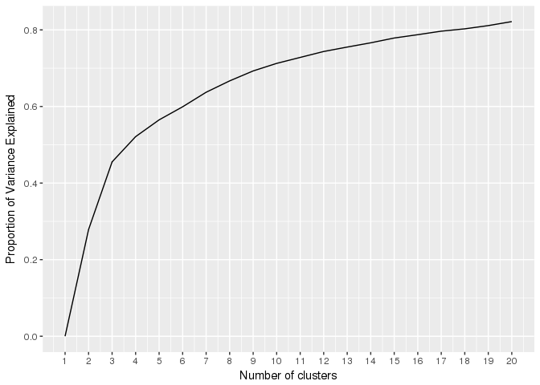

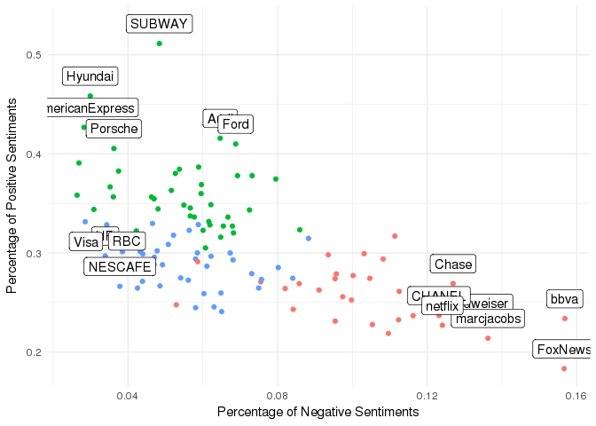

### Bing Dictionary

The NRC dictionary doesn’t seem large enough to fit so many emotions, and we find too much overlap within positive and negative emotions. So, we change our sentiment dictionary to the Bing dictionary, which classifies words as simply positive or negative. As a result, we can find a net sentiment rating by taking the difference in frequencies of positive and negative words.

Sentiment scores are mainly a function of frequency of tweeting, so we plot the two variables against each other. We notice that Starbucks, McDonald’s, T-Mobile, Xbox, Walmart, and LEGO are all examples of brands that use more positive words than expected. On the other hand, airlines like Southwest and Delta have a lower sentiment score than a linear model predicts. Additionally, Google and Fox News have noticeably smaller sentiment scores for how often they tweet. Fox News is the only brand to have a negative sentiment score.

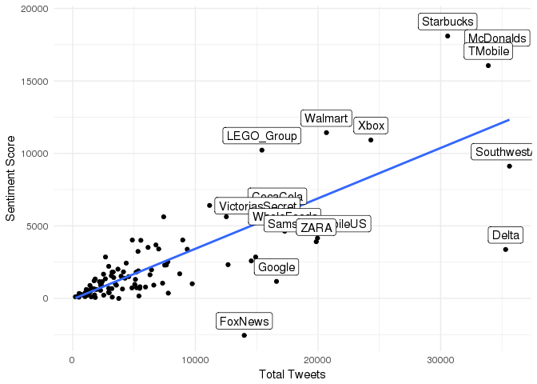

We look at the most frequently used words by each company. Costco received a lot of backlash over its logo being on Breitbart News, and replied to users assuring that it is not affiliated with Breitbart News. Companies like Disney, Subway, Visa, and others frequently promote a hashtag for their marketing campaign. Other companies like Ford or Verizon focus on customer relations, and direct people to (direct) message the company through Twitter or customer service.

| screenName | word | n | total | freq |
| --- | --- | --- | --- | --- |
| Costco | breitbart | 2844 | 8535 | 0.3332162 |
| Ford | message | 9476 | 61926 | 0.1530213 |
| Disney | #chooseyourpath | 3062 | 21197 | 0.1444544 |
| SUBWAY | #nationalsandwichday | 2594 | 20551 | 0.1262226 |
| Visa | #applepay | 1578 | 13617 | 0.1158846 |
| Budweiser | #thisbudsforyou | 3670 | 32326 | 0.1135309 |
| Fritolay | call | 4718 | 43966 | 0.1073102 |
| verizon | dm | 8440 | 79924 | 0.1056003 |
| Hyundai | hyundai | 3204 | 34932 | 0.0917211 |
| Hermes_Paris | herm | 166 | 1852 | 0.0896328 |
| Heineken | #championthematch | 2415 | 27115 | 0.0890651 |
| LouisVuitton | #louisvuitton | 2244 | 25389 | 0.0883847 |
| redbull | wings | 2181 | 24687 | 0.0883461 |
| Pampers | call | 515 | 5966 | 0.0863225 |
| Google | steps | 7082 | 92793 | 0.0763204 |
| Mastercard | dm | 1749 | 24763 | 0.0706296 |
| AmericanExpress | connecting | 1985 | 28154 | 0.0705051 |
| CanonUSA | canon | 1617 | 23062 | 0.0701153 |
| Porsche | #porschecares | 523 | 7625 | 0.0685902 |
| TOMS | supporting | 2457 | 36166 | 0.0679367 |
| ATT | dm | 5879 | 87062 | 0.0675266 |
| WholeFoods | store | 5014 | 75525 | 0.0663886 |
| VictoriasSecret | dm | 4373 | 68425 | 0.0639094 |
| SantanderBankUS | dm | 1262 | 20647 | 0.0611227 |
| Prada | prada | 1430 | 23583 | 0.0606369 |
| bbva | de | 2898 | 49398 | 0.0586663 |
| marcjacobs | marc | 573 | 9853 | 0.0581549 |
| Android | android | 2098 | 37404 | 0.0560903 |
| Gap | hear | 2245 | 42446 | 0.0528907 |
| Lexus | km | 1907 | 36126 | 0.0527875 |

[output cut: 85 more lines]

We look at a table of the most frequently used words in replies and non-replies.

As expected, non-replies use words marketing the company’s products, such as “collection” for a collection of items or clothes, “watch” for promotional videos, “time” in anticipation for upcoming product releases, and so on.

Replies include words indicative of customer management, using words like “happy” or “love” to show eagerness, and words like “sharing” or “hear” to acknowledge and engage with brand loyalists.

| NonReplyWord | ReplyWord |
| --- | --- |
| collection | dm |
| watch | hear |
| time | love |
| day | happy |
| live | send |
| learn | glad |
| de | hope |
| check | team |
| world | time |
| shop | check |
| ready | message |
| #louisvuitton | sharing |
| la | call |
| campaign | details |
| wearing | day |
| love | enjoy |
| summer | assist |
| future | share |
| discover | contact |
| happy | email |
| business | store |
| week | hey |
| people | feedback |
| game | follow |
| digital | account |
| canon | service |
| join | experience |
| home | info |
| free | sounds |
| season | awesome |

## Topic Modeling

### Word Ratios

If we’re creating topic models, we would expect natural topics to arise between replies and non-replies. We can first look at log ratios of word frequencies between replies and non-replies to identify words that are distinctive of replies and non-replies.

```
## # A tibble: 6,825 x 4
##    word       no_reply     reply   logratio
##    <chr>         <dbl>     <dbl>      <dbl>
##  1 bear      0.0000893 0.0000893  0.0000620
##  2 addition  0.0000920 0.0000921  0.00102
##  3 apple     0.000200  0.000201   0.00358
##  4 mark      0.000428  0.000430   0.00413
##  5 price     0.000279  0.000277  -0.00433
##  6 appears   0.0000760 0.0000763  0.00461
##  7 guys      0.000277  0.000279   0.00471
##  8 standards 0.0000693 0.0000696  0.00471
##  9 choose    0.000299  0.000301   0.00673
## 10 figure    0.0000706 0.0000700 -0.00870
## # ... with 6,815 more rows
```

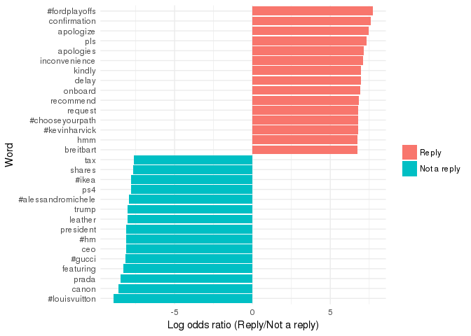

### LDA (Latent Dirichlet allocation)

I tried modeling a Latent Dirichlet allocation (LDA) with 2, 3, and 4 topics. However, there didn’t seem to be a distinct separation of tweets - I was expecting a clearer line between sales, customer service, and possibly general announcements. With such a large dataset, it is more common to use a larger number of topics. Unfortunately, we don’t have computational power to fit that many topics. Stemming words helps efficiency somewhat, but modelling more than 4 topics still takes a long time.

The reason we’re interested in topics in the first place is to find a natural clustering of what companies tweet. We can get a better understanding of how social media is used by companies, and how companies communicate with consumers in general.

```
##
Read 63.7% of 3847279 rows
Read 3847279 rows and 8 (of 8) columns from 0.197 GB file in 00:00:03
```

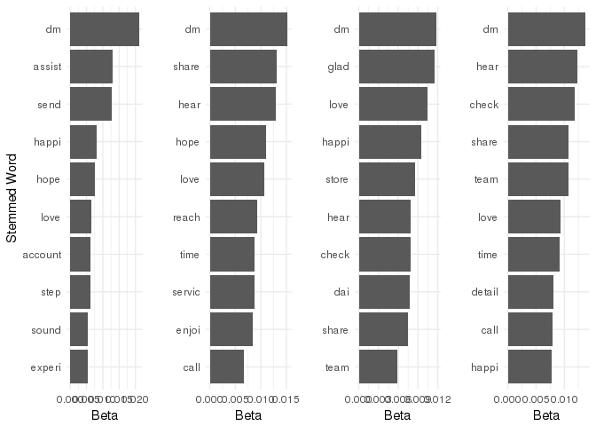

Let’s focus on just non-replies so that we can ignore many of the common words used in customer service, to improve efficiency, and to form topics specifically on how companies market to consumers. We remove tweets from bbva because we find that many of the common words from Spanish are muddling results.

There isn’t a great statistical method for choosing and evaluating the number of topics in the model. We settle on 3 topics because each topic has a similar distribution of beta values.

Unfortunately, the topics are very similar and have a lot of word overlap. I don’t see broad similaries between words within each topic.

```
##
Read 64.3% of 3857389 rows
Read 3857389 rows and 8 (of 8) columns from 0.201 GB file in 00:00:03
```

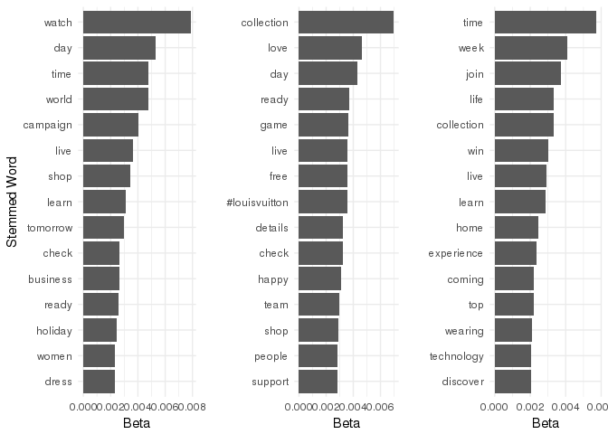

## Linear Modelling

We can try to find covariates that correspond to more popular tweets, using either favorites or retweets as an outcome measure. Specifically, we’re interested in whether using positive or negative words can influence the popularity of a tweet, whether by using stronger words or by tapping an emotional appeal. We remove replies because they aren’t given as much exposure as regular tweets.

From a basic plot of sentiment score against retweets, it seems that using negative words can increase the number of retweets.

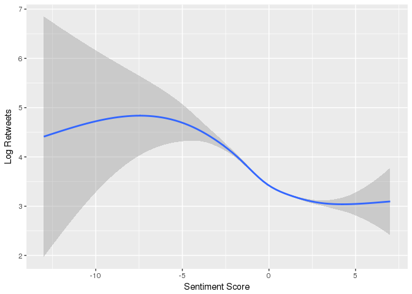

Positive and negative word frequencies are not normally distributed and very few values. We will subset our dataset to only include tweets with 4 or less positive words, and 3 or less negative words because higher values have larger variance and leverage, which would make our estimates unstable. We also use both variables as categorical variables to circumvent assumptions of normality.

We also remove tweets by BBVA to reduce noise from Spanish tweets.

```
## positive
##     0     1     2     3     4     5     6     7
## 96550 42322 11726  2468   407    63     9     1
```

```
## negative
##      0      1      2      3      4      5     13
## 129865  19921   3189    476     84     10      1
```

We also find a correlation coefficient of 0.94 between log retweets and favorites, so we don’t expect too much of a difference when using them as outcome measures. It also wouldn’t make sense to use either as a covariate because they’re both measuring the same construct - how “large” a tweet is.

We fit a linear regression model with log retweets as a response variable. We include covariates for the number of positive words used (`positive`), the number of negative words used (`negative`), and their interaction (`positive:negative`). We also included company and monthly time fixed effects to control for company popularity and the overall popularity of Twitter over time.

Additionally, the interactions between positive and negative words also produce generally positive estimates (save for a few terms without explanatory power). That means that adding positive or negative words will tend to give you more popular tweets in general.

To interpret coefficients explicitly, our model predicat that going from no emotional words to a single positive word in a tweet would give a 1.8% increase in retweets. Going from no emotional words to two positive words would give a 5.2% increase in retweets.

The model had an adjusted R2 of 0.6655 (not shown). That is surprisingly large, but it mostly due to the model’s fixed effects.

```
## Call
## lm(formula = logRTs ~ positive * negative + screenName + as.factor(year) *
##     as.factor(month), data = all)
##
## Residuals
##     Min.  1st Qu.   Median     Mean  3rd Qu.     Max.
## -5.93872 -0.54751 -0.02858  0.00000  0.49685  8.72160
##
##                          Estimate  Std. Error     t value     Pr(>|t|)
## positive1            0.0182643761 0.006397401  2.85496827 4.304702e-03
## positive2            0.0504973331 0.010503731  4.80756174 1.529297e-06
## positive3            0.0712598173 0.021592363  3.30023246 9.662726e-04
## positive4            0.0652722446 0.052912237  1.23359451 2.173560e-01
## negative1            0.0003227861 0.009542489  0.03382620 9.730158e-01
## negative2            0.0488107420 0.021398143  2.28107374 2.254548e-02
## negative3            0.0686248547 0.054064516  1.26931413 2.043310e-01
## positive1:negative1  0.0437903393 0.017491353  2.50354209 1.229676e-02
## positive2:negative1  0.0634132528 0.031754029  1.99701438 4.582542e-02
## positive3:negative1  0.0253639888 0.070422476  0.36016895 7.187213e-01
## positive4:negative1 -0.0105543836 0.165782723 -0.06366395 9.492379e-01
## positive1:negative2  0.0167579476 0.043353213  0.38654454 6.990940e-01
## positive2:negative2 -0.1515322161 0.083870560 -1.80673905 7.080498e-02
## positive3:negative2  0.0599764551 0.152579014  0.39308456 6.942576e-01
## positive4:negative2  0.4188726456 0.319224771  1.31215583 1.894696e-01
## positive1:negative3 -0.0858114735 0.109020369 -0.78711414 4.312163e-01
## positive2:negative3  0.1820897578 0.234183544  0.77755147 4.368347e-01
## positive3:negative3 -0.5411424611 0.499497698 -1.08337328 2.786445e-01
## positive4:negative3  1.0271934957 0.994882018  1.03247770 3.018501e-01
##
## Residual standard error: 0.992 on 150208 degrees of freedom
## F-statistic: 1439.6 on 208 and 150208 DF, p-value: <2e-16
```

We check for consistent effects by running the same linear regression except using log favorites as our response variable.

Despite retweets and favorites being highly correlated, we find very different effects. We see that including positive words tends to increase favorites. While our coefficients are larger, tweets tend to have more favorites, so we can’t compare effect sizes. However, including negative words tends to DECREASE the tweet’s number of favorites. Interaction terms suggest that favorites tend to increase by a small amount from increasing the number of emotional words.

The model predicts that going from a tweet with no emotional words to one positive word would increase favorites by 4.9%. The model also predicts that adding a negative word to a tweet with no emotional words would decrease favorites by 4.0%.

```
## Call
## lm(formula = logFavs ~ positive + negative + positive:negative +
##     screenName + as.factor(year) * as.factor(month), data = all)
##
## Residuals
##     Min.  1st Qu.   Median     Mean  3rd Qu.     Max.
## -7.28099 -0.52040 -0.01581  0.00000  0.50141  7.23914
##
##                        Estimate  Std. Error     t value     Pr(>|t|)
## positive1            0.04821927 0.006620191  7.28366657 3.264495e-13
## positive2            0.09868123 0.010869525  9.07870716 1.111513e-19
## positive3            0.13325140 0.022344321  5.96354678 2.473697e-09
## positive4            0.14586553 0.054754914  2.66397139 7.723237e-03
## negative1           -0.04059914 0.009874808 -4.11138540 3.935008e-05
## negative2           -0.04384301 0.022143337 -1.97996381 4.770942e-02
## negative3           -0.11932656 0.055947322 -2.13283768 3.293966e-02
## positive1:negative1  0.06243813 0.018100493  3.44952669 5.617243e-04
## positive2:negative1  0.08246570 0.032859869  2.50961755 1.208724e-02
## positive3:negative1  0.07828885 0.072874950  1.07429030 2.826943e-01
## positive4:negative1  0.02419487 0.171556135  0.14103179 8.878450e-01
## positive1:negative2  0.08212994 0.044862996  1.83068340 6.714979e-02
## positive2:negative2 -0.08527476 0.086791367 -0.98252583 3.258424e-01
## positive3:negative2  0.05910958 0.157892605  0.37436572 7.081328e-01
## positive4:negative2  0.30235359 0.330341829  0.91527491 3.600488e-01
## positive1:negative3 -0.00152504 0.112817022 -0.01351782 9.892147e-01
## positive2:negative3  0.35921863 0.242339026  1.48229789 1.382631e-01
## positive3:negative3 -0.23519889 0.516892791 -0.45502452 6.490923e-01
## positive4:negative3  0.74433527 1.029528955  0.72298624 4.696895e-01
##
## Residual standard error: 1.026 on 150208 degrees of freedom
## F-statistic: 1764.42 on 208 and 150208 DF, p-value: <2e-16
```